[figure not shown]

# Predicting news popularity in social media (C1)

### Final Delivery

Artificial Intelligence (IART)

3<sup>rd</sup> year of Integrated Masters in Informatics and Computing Engineering

### Project Authors

- Bruno Vale Fernandes up200707284@fe.up.pt
- Fábio Oliveira up201604796@fe.up.pt
- Ricardo Boia up201505244@fe.up.pt

Social network sites are becoming essential to how people experience news. For this project we developed supervised machine learning models to predict the popularity of news for the topics Obama, Economy, Palestine and Microsoft on the following social networks: Facebook, Google+ and LinkedIn.

The dataset we used can be found [here](http://archive.ics.uci.edu/ml/datasets/News+Popularity+in+Multiple+Social+Media+Platforms).

*May 21<sup>th</sup>, 2019*

# Code

### Install additional dependencies.

```python
!pip install matplotlib-venn;
```

```
     |████████████████████████████████| 40kB 2.1MB/s eta 0:00:01
```

```python
import pandas as pd
import numpy as np
import matplotlib.pyplot as plt
import seaborn as sns
from sklearn.preprocessing import LabelEncoder, MinMaxScaler, PolynomialFeatures
from sklearn.model_selection import train_test_split
from sklearn.pipeline import make_pipeline
from sklearn.linear_model import LinearRegression
from sklearn.neighbors import KNeighborsRegressor
from sklearn import metrics
from dateutil.parser import parse
from matplotlib_venn import venn3_unweighted
from IPython.display import Markdown
```

### Define constants.

```python
DATASET_PATH = "dataset/News_Final.csv"
TRAIN_SET_SIZE = 0.70 # Use 70% of data to train the model and 30% to test it.
FEATURES = ["Topic", "PublishDay", "PublishHour", "SentimentTitle", "SentimentHeadline"]
RESPONSES = ["Facebook", "GooglePlus", "LinkedIn"]
COLORS = {"Facebook": "blue", "GooglePlus": "orange", "LinkedIn": "green"}
```

### Load data.

```python
data = pd.read_csv(DATASET_PATH, index_col=0)

print("{} samples found in {}.".format(data.shape[0], DATASET_PATH))
```

```
93239 samples found in dataset/News_Final.csv.
```

```python
# display last 5 samples.
data.tail()
```

| IDLink | Title | Headline | Source | Topic | PublishDate | SentimentTitle | SentimentHeadline | Facebook | GooglePlus | LinkedIn |
| --- | --- | --- | --- | --- | --- | --- | --- | --- | --- | --- |
| 61851.0 | Stocks rise as investors key in on US economy ... | The June employment report is viewed as a cruc... | MarketWatch | economy | 2016-07-07 15:31:05 | 0.104284 | 0.044943 | -1 | 3 | 5 |
| 61865.0 | Russian PM proposes to use conservative and to... | In addition, establish stimulating economic po... | TASS | economy | 2016-07-07 15:31:10 | 0.072194 | 0.000000 | -1 | 0 | 1 |
| 104793.0 | Palestinian Government Uses Foreign Aid To Pay... | The Palestinian government spends nearly $140 ... | Daily Caller | palestine | 2016-07-07 15:38:26 | 0.291667 | -0.139754 | 5 | 1 | 0 |
| 104794.0 | Palestine Youth Orchestra prepares for first U... | Palestine Youth Orchestra prepares for first U... | Ahram Online | palestine | 2016-07-07 15:59:22 | 0.121534 | 0.092313 | 0 | 0 | 0 |
| 61870.0 | Sausalito businesswoman wins $10000 in Microso... | Goldstein, the proprietor of the TG Travel Gro... | East Bay Times | microsoft | 2016-07-07 16:16:11 | 0.000000 | 0.054554 | -1 | 1 | 0 |

- **IDLink** is a unique number that represents the news article.
- **Title** is the article's title.
- **Headline** is the article's headline.
- **Source** is the name of the news outlet that published the article.
- **Topic** is the topic of the article. Can be one of the following: Obama, Economy, Palestine and Microsoft.
- **PublishDate** is the date and time of the article's publication.
- **SentimentTitle** is a sentiment score for the article's title. Ranges from -1 (negative) to +1 (positive).
- **SentimentHeadline** is a sentiment score for the article's headline. Ranges from -1 (negative) to +1 (positive).
- **Facebook** is the number of times the news was shared on Facebook.
- **GooglePlus** is the number of times the news was shared on GooglePlus.
- **LinkedIn** is the number of times the news was shared on LinkedIn.

### Preprocess data.

```python
# Encode topic feature so it can used with sk-learn models.
topic_encoder = LabelEncoder()
topic_encoder.fit(data['Topic'].astype(str))
data['Topic'] = topic_encoder.transform(data['Topic'].astype(str))

# Extract PublishDay and PublishHour from PublishDate.
data['PublishDay'] = data['PublishDate'].astype(str).apply(lambda x: parse(x).weekday())
data['PublishHour'] = data['PublishDate'].astype(str).apply(lambda x: parse(x).hour)
data['_PublishHour'] = data['PublishHour']; # Save non-normalized PublishHour for later.

# Normalize PublishDay and PublishHour to interval [0,1].
min_max_scaler = MinMaxScaler()
data[['PublishDay']] = min_max_scaler.fit_transform(data[['PublishDay']].astype(float))
data[['PublishHour']] = min_max_scaler.fit_transform(data[['PublishHour']].astype(float))

X = data[FEATURES]  # Input variables.
Y = data[RESPONSES] # Output variables. A ML model will be developed for each.
```

```python
# Display last 5 sample's features.
X.tail()
```

| IDLink | Topic | PublishDay | PublishHour | SentimentTitle | SentimentHeadline |
| --- | --- | --- | --- | --- | --- |
| 61851.0 | 0 | 0.5 | 0.652174 | 0.104284 | 0.044943 |
| 61865.0 | 0 | 0.5 | 0.652174 | 0.072194 | 0.000000 |
| 104793.0 | 3 | 0.5 | 0.652174 | 0.291667 | -0.139754 |
| 104794.0 | 3 | 0.5 | 0.652174 | 0.121534 | 0.092313 |
| 61870.0 | 1 | 0.5 | 0.695652 | 0.000000 | 0.054554 |

```python
# Display last 5 sample's responses.
Y.tail()
```

| IDLink | Facebook | GooglePlus | LinkedIn |
| --- | --- | --- | --- |
| 61851.0 | -1 | 3 | 5 |
| 61865.0 | -1 | 0 | 1 |
| 104793.0 | 5 | 1 | 0 |
| 104794.0 | 0 | 0 | 0 |
| 61870.0 | -1 | 1 | 0 |

### Helper Functions.

```python
# Returns the training set and testing set for a given social network.
# This is required because not all news are published in all of them.
def get_sets(social_network):
    sn_y_train = Y_train[Y_train[social_network] >= 0]
    sn_X_train = X_train[X_train.index.isin(sn_y_train.index)].dropna()
    sn_y_test = Y_test[Y_test[social_network] >= 0]
    sn_X_test = X_test[X_test.index.isin(sn_y_test.index)].dropna()
    return sn_X_train, sn_y_train[social_network], sn_X_test, sn_y_test[social_network]
```

### Data Insights.

Note: the light blue bounds in the plots represent a 95% confidence interval.

- Average news popularity by week day of publication.

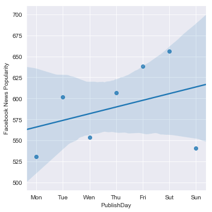

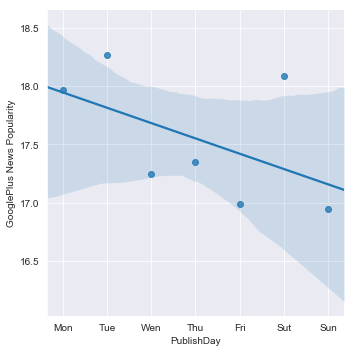

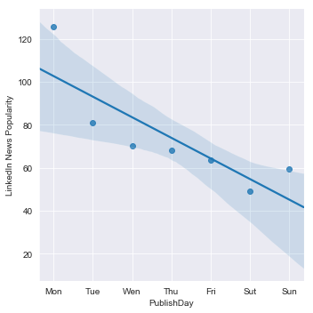

```python
sns.set_style("darkgrid")

WEEK_DAYS = ['Mon', 'Tue', 'Wed', 'Thu', 'Fri', 'Sat', 'Sun']

for social_network in RESPONSES:
    pp = sns.pairplot(data=data.groupby('PublishDay', as_index=False).mean(), x_vars='PublishDay', y_vars=social_network, height=5, kind='reg').set(ylabel='{} News Popularity'.format(social_network))
    pp.axes[0,0].set_xticklabels(['Mon','Tue','Wen','Thu','Fri','Sut','Sun'])
    pp.axes[0,0].set_xticks([0, 1/6, 2/6, 3/6, 4/6, 5/6, 1])
```

- Average news popularity by hour of publication.

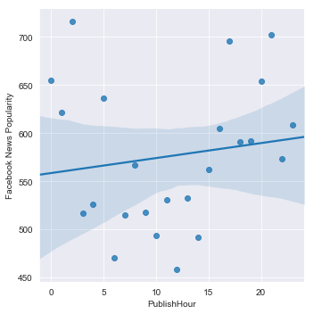

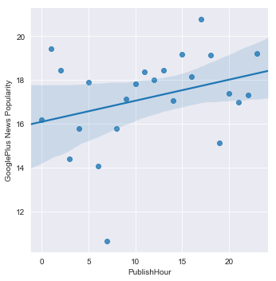

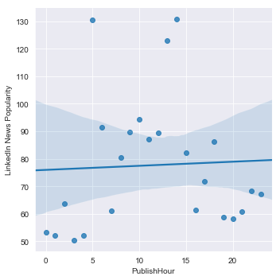

```python
sns.set_style("darkgrid")
for social_network in RESPONSES:
    pp = sns.pairplot(data=data.groupby('_PublishHour', as_index=False).mean(), x_vars='_PublishHour', y_vars=social_network, height=5, kind='reg').set(xlabel="PublishHour",ylabel='{} News Popularity'.format(social_network))
```

- News popularity by title's and headline's sentiment.

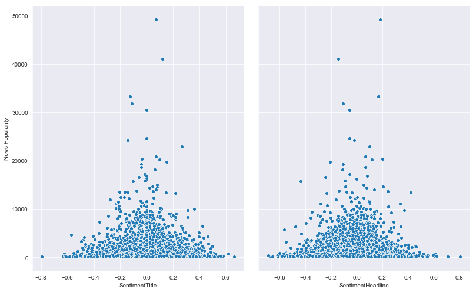

```python
sns.set_style("darkgrid")

data["total"] = data["Facebook"] + data["LinkedIn"] + data["GooglePlus"]
data = data[data["total"] >= 100] # Filter junk data.
sns.pairplot(data, x_vars=['SentimentTitle', 'SentimentHeadline'], y_vars='total', height=7, aspect=0.8, kind='scatter').set(ylabel='News Popularity');
```

- News shared in each social network.

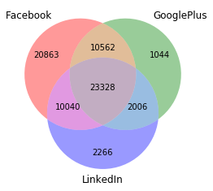

```python
facebook = data[data["Facebook"] > 0].index
gplus = data[data["GooglePlus"] > 0].index
linkedin = data[data["LinkedIn"] > 0].index
venn3_unweighted(subsets=[set(facebook), set(gplus), set(linkedin)], set_labels = ('Facebook', 'GooglePlus', 'LinkedIn'));
```

### Split Data into Training Set and Test Set.

- **Training Set**: X_train and Y_train.
- **Testing Set**: X_test and Y_test.

```python
X_train, X_test, Y_train, Y_test = train_test_split(X, Y, test_size=(1-TRAIN_SET_SIZE), random_state=0)
display(Markdown("Split data into **training set** ({}%, {} rows) and **testing set** ({}%, {} rows).".format(round(TRAIN_SET_SIZE,2)*100, X_train.index.size, round(1-TRAIN_SET_SIZE,2)*100, X_test.index.size)))
```

Split data into **training set** (70.0%, 65267 rows) and **testing set** (30.0%, 27972 rows).

## Building the ML models.

In this section we proceed to train and test several Machine Learning models using popular regression algorithms.

The metrics we will be using to evaluate those models are the **Root Mean Square Error** (RMSE), which is the square root of the mean of the squared errors, and the **Coefficient of Determination** (R²), which measures how well a model explains the variance in the data.

### Linear and Polynomial Regression.

**Polynomial Regression** is a form of regression analysis in which the relationship between the independent variables X and the dependent variable *y* is modeled as an nth degree polynomial in *x*.

**Linear regression** can be thought as a particular case of **Polynomial Regression** in which the polynomial degree *n* is 1.

```python
for degree in range(1,5):
    print('\r')
    if(degree == 1):
        print("Linear regression.")
    else:
        print("Polynomial regression, degree = {}.".format(degree))
    for social_network in RESPONSES:
        sn_X_train, sn_y_train, sn_X_test, sn_y_test = get_sets(social_network)
        lr_model = make_pipeline(PolynomialFeatures(degree), LinearRegression())
        lr_model.fit(sn_X_train, sn_y_train)
        sn_y_pred = lr_model.predict(sn_X_test)
        print("[{}] RMSE: {}".format(social_network, np.sqrt(metrics.mean_squared_error(sn_y_test, sn_y_pred))))
        print("[{}] R^2: {}".format(social_network, metrics.r2_score(sn_y_test, sn_y_pred)))
```

```
Linear regression.
[Facebook] RMSE: 664.1011224268102
[Facebook] R^2: 0.013521214179805008
[GooglePlus] RMSE: 20.39986222623975
[GooglePlus] R^2: 0.005860464236229657
[LinkedIn] RMSE: 98.31866519340444
[LinkedIn] R^2: 0.001350236016830486

Polynomial regression, degree = 2.
[Facebook] RMSE: 662.4072650867852
[Facebook] R^2: 0.01854702517889739
[GooglePlus] RMSE: 20.336481305037495
[GooglePlus] R^2: 0.012028309479154897
[LinkedIn] RMSE: 98.24156233242569
[LinkedIn] R^2: 0.0029159318492958386

Polynomial regression, degree = 3.
[Facebook] RMSE: 656.7965896385655
[Facebook] R^2: 0.03510268068137912
[GooglePlus] RMSE: 20.32247017285454
[GooglePlus] R^2: 0.013389197157252175
[LinkedIn] RMSE: 98.15982241858943
[LinkedIn] R^2: 0.004574449039282835

Polynomial regression, degree = 4.
[Facebook] RMSE: 657.0556747659788
[Facebook] R^2: 0.034341288629486044
[GooglePlus] RMSE: 20.32892537590358
[GooglePlus] R^2: 0.012762326064028384
[LinkedIn] RMSE: 98.30736158440001
[LinkedIn] R^2: 0.0015798505571963384
```

### K-Nearest Neighbors (KNN).

The goal of **KNN** is to predict a new observation response by looking up the most similar *K* train test samples.

It can be used in regression and classification problems.

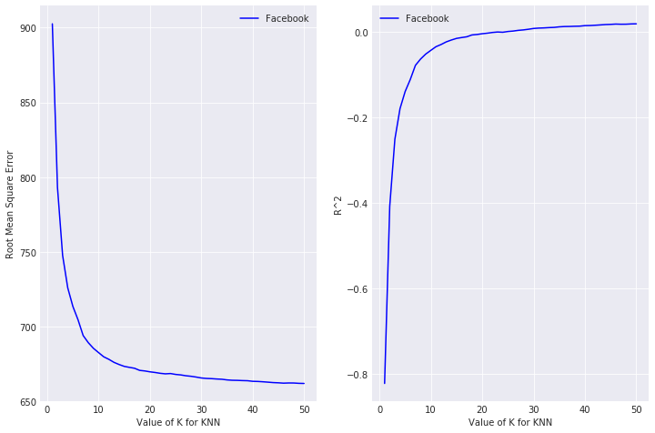

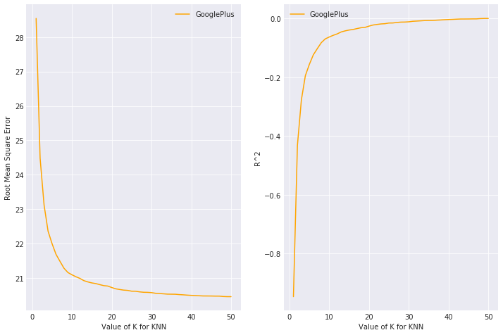

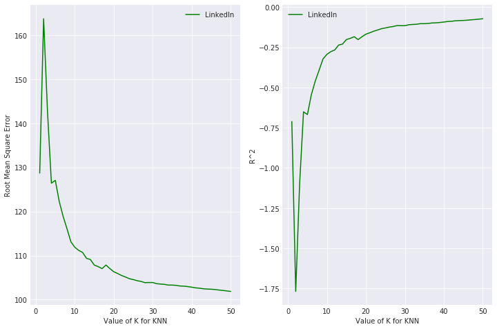

```python
# Test with k from 1 to 50
k_range = list(range(1, 51))

k_rmse = {}
k_k2 = {}
for social_network in RESPONSES:
    k_rmse[social_network] = []
    k_k2[social_network] = []
    for k in k_range:
        knn = KNeighborsRegressor(n_neighbors=k)
        sn_X_train, sn_y_train, sn_X_test, sn_y_test = get_sets(social_network)
        knn.fit(sn_X_train, sn_y_train)
        y_pred = knn.predict(sn_X_test)
        k_rmse[social_network].append(np.sqrt(metrics.mean_squared_error(sn_y_test, y_pred)))
        k_k2[social_network].append(metrics.r2_score(sn_y_test, y_pred))

# Display plots.
sns.set_style("darkgrid")
for social_network in RESPONSES:
    plt.figure(figsize=(12,8))
    plt.subplot(1, 2, 1)
    plt.plot(k_range, k_rmse[social_network], label=social_network, color = COLORS[social_network])
    plt.xlabel('Value of K for KNN')
    plt.ylabel('Root Mean Square Error')
    plt.legend()
    plt.subplot(1, 2, 2)
    plt.plot(k_range, k_k2[social_network], label=social_network, color = COLORS[social_network])
    plt.xlabel('Value of K for KNN')
    plt.ylabel('R^2')
    plt.legend()
    plt.show()
```

### Support-Vector Regression (SVR).

A SVR performs linear regression in higher dimensional space. Each data point in the training represents its own dimension. When the kernel is evaluated between a test point and a training point, the resulting value gives the coordinate to the test point in that dimension.

```python
from sklearn.svm import SVR

svr_model = SVR(gamma=.1, C=100, epsilon=.1)
for social_network in RESPONSES:
        sn_X_train, sn_y_train, sn_X_test, sn_y_test = get_sets(social_network)
        svr_model.fit(sn_X_train, sn_y_train)
        sn_y_pred = svr_model.predict(sn_X_test)
        sn_rmse = np.sqrt(metrics.mean_squared_error(sn_y_test, sn_y_pred))
        sn_r2 = metrics.r2_score(sn_y_test, sn_y_pred)
        print("[{}] RMSE: {} - R^2: {}".format(social_network, sn_rmse, sn_r2))
```

```
[Facebook] RMSE: 675.8607814585222 - R^2: -0.02172451521888452
[GooglePlus] RMSE: 20.76147714986243 - R^2: -0.02969683119756672
[LinkedIn] RMSE: 99.54524128354801 - R^2: -0.023722534745709956
```

### Neural Network.

Artificial neural network are computational networks based on biological neural networks. These models aim to replicate the complex network of neurons in our brains.

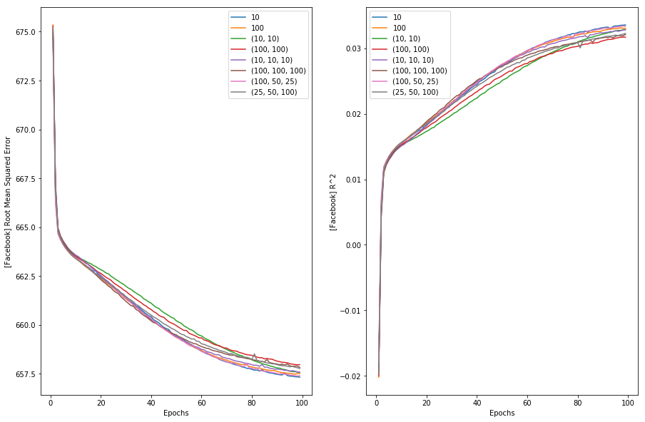

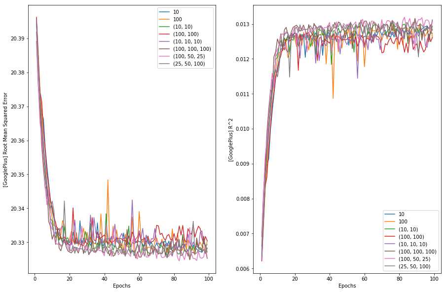

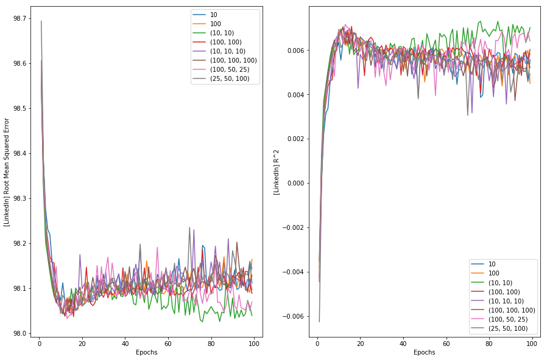

```python
from sklearn.neural_network import MLPRegressor


for social_network in RESPONSES:
    plt.figure(figsize=(15,10))
    sn_X_train, sn_y_train, sn_X_test, sn_y_test = get_sets(social_network)

    INNER_LAYERS = [
        (10),
        (100),
        (10, 10),
        (100, 100),
        (10, 10, 10),
        (100, 100, 100),
        (100, 50, 25),
        (25, 50, 100)
    ]

    N_TRAIN_SAMPLES = sn_X_train.shape[0]
    N_EPOCHS = 100
    N_EPOCHS_RANGE = list(range(1, N_EPOCHS))
    N_BATCH = sn_X_train.shape[0]
    scores_rmse = {}
    scores_r2 = {}

    for layers_size in INNER_LAYERS:
        nn_model = MLPRegressor(activation='relu',solver='adam', early_stopping=False, warm_start=True, max_iter=2000)
        epoch = 1
        scores_rmse[layers_size] = []
        scores_r2[layers_size] = []
        while epoch < N_EPOCHS:
            nn_model.partial_fit(sn_X_train, sn_y_train)

            # SCORE TEST
            y_pred = nn_model.predict(sn_X_test)
            scores_rmse[layers_size].append(np.sqrt(metrics.mean_squared_error(sn_y_test, y_pred)))
            scores_r2[layers_size].append(metrics.r2_score(sn_y_test, y_pred))

            epoch += 1

    plt.subplot(1, 2, 1)
    for layers_size in INNER_LAYERS:
        plt.plot(N_EPOCHS_RANGE, scores_rmse[layers_size], label=str(layers_size))
    plt.ylabel('[{}] Root Mean Squared Error'.format(social_network))
    plt.xlabel('Epochs')
    plt.legend()

    plt.subplot(1, 2, 2)
    for layers_size in INNER_LAYERS:
        plt.plot(N_EPOCHS_RANGE, scores_r2[layers_size], label=str(layers_size))
    plt.ylabel('[{}] R^2'.format(social_network))
    plt.xlabel('Epochs')
    plt.legend()
    plt.show()
```